# Prior_Simulation

Adam C. Smith

26/08/2021

```
## To access larger datasets in this package, install the spDataLarge
## package with: `install.packages('spDataLarge',
## repos='https://nowosad.github.io/drat/', type='source')`
```

```
## character(0)
```

## Priors for the spatial variance in GAM parameters

The stratum-level population trajectories are fit using a spatially explicit, hierarchical GAM smooth. This spatial hierarchical structure allows the model to share information on the shape of the population trajectory among neighbouring strata and across the full range of the sites monitored for a given species. The variation among strata in the shape of the population trajectory is estimated using an intrinsic conditional autoregressive (iCAR) structure. This iCAR component of the model estimates the parameters of the GAM smooth as drawn from a normal distribution centered on the means of the parameter values in the neighbouring strata and with an estimated standard deviation (SD). The value of the SD controls the amount of variation in the shape of the trajectories among strata.

### Simulation

We simulated population trajectories from the model, using estimated parameter values for Semipalmated Plover for all parameters except the stratum-level GAM parameters. We chose to use Semipalmated Plover as the example species in the simulation so that the simulated data would closely match real data and because the Semipalmated Plover mean population trajectory is largely stable through time. Simulating a stable population allowed us to more intuitively assess the variation in population trends in the simulated data.

```r
sp1 = "Semipalmated Plover"


    spf1 = "Semipalmated_Plover"
    sp_file_name1 <- "Semipalmated_Plover-gamma-t"

    #loading the original data
    load(paste0("data/data",sp1,"_cmdstanr_data.RData"))
    #loading the objects saved after model run
    load(paste0(output_dir,"/",sp_file_name1,"_fit_add.RData"))

# commented out section run in separate session to avoid loading the large cmdstan output
#     ## load the stan csv files that include the model output for SEPL
#     cmdstanfit <- rstan::read_stan_csv(csvfl)
#
#
# # Gather parameter estimates from fitted model --------------------------------------
#
#     #posterior samples of site-level effects
#     alpha_samples <- posterior_samples(fit = cmdstanfit,
#                                        parm = "alpha",
#                                        dims = c("s"))
#
#     #posterior samples of the overall intercept
#     ALPHA1_samples <- posterior_samples(fit = cmdstanfit,
#                              parm = "ALPHA1",
#                              dims = NULL)
#
#
#     #posterior samples of overdispersion variance
#     sdnoise <- posterior_samples(fit = cmdstanfit,
#                                 parm = "sdnoise",
#                                 dims = NULL) %>%
#        summarise(mean = mean(.value)) %>%
#        as.numeric()
#
#     #posterior samples of variance in year-effects
#     sdyear <- posterior_samples(fit = cmdstanfit,
#                                  parm = "sdyear",
#                                  dims = NULL) %>%
#       summarise(mean = mean(.value)) %>%
#       as.numeric()
#
#
#
#
#     #posterior samples of hyperparameter GAM parameters (survey-wide mean population trajectory)
#     B_samples <- posterior_samples(fit = cmdstanfit,
#                                   parm = "B",
#                                   dims = c("k"))
#
#
#     save(list = c("stan_data",
#                   "B_samples",
#                   "sdyear",
#                   "sdnoise",
#                   "alpha_samples",
#                   "ALPHA1_samples"),
#          file = "data/temp_SEPL_output.RData")


    load("data/temp_SEPL_output.RData")
```

## Generate the simulated stratum-level trajectories using the prior distributions

We used the realised adjacency matrix for SEPL monitoring data to generate the distribution of stratum-level GAM parameters.

```r
#neighbourhood matrix from the original species data
    nmat = matrix(0,nrow = stan_data$nstrata,ncol = stan_data$nstrata)
    for(j in 1:stan_data$N_edges){
      ss = stan_data$node1[j]
      ss2 = stan_data$node2[j]
      nmat[ss,ss2] <- 1
      nmat[ss2,ss] <- 1

    }


    # blank object to hold simulated trends
    Trends_comp_out <- NULL
    #number of simulations = number of posterior draws from the fitted model
    niter = max(B_samples$.draw)
```

We used gamma priors as weakly informative, boundary-avoiding priors on the SD. All gamma priors had a shape parameter = 2, so that the mode of the prior distribution = 1/rate, following (Chung et al. 2013). USing a gamma distribution excludes values of 0 from the prior on the SD. We assessed four alternative rate parameters c(0.5,1,2,4). This selection of parameter values allow the priors to span a wide range of distributions, where the prior modes range from 0.25 (4) to 2 (0.5) and the upper 95 percentile of prior distributions range from 1.2 (4) to 10 (0.5).

```r
rates = c(0.5,2,1,4)
```

Then we simulated the stratum-level trajectories using the real data from each posterior draw of the SEPL model output and the proposed prior distribution of SD values for the GAM parameters in each stratum.

```r
   for(prior_rate in rates){
      #samples from the prior
    sdyear_gam_sim <- rgamma(niter,2,prior_rate)

    #blank array to hold the simulated population trajectories from which the trends are generated
    nsmooth <- array(NA,dim = c(niter,stan_data$nstrata,stan_data$nyears))

    for(i in 1:niter){

      #blank matrix to hold the yearly predictions of the smooths
      year_pred <- matrix(NA,nrow = stan_data$nyears,ncol = stan_data$nstrata)
      # blank matrix to hold the simulated stratum-level GAM parameters
      b <- matrix(NA,nrow = stan_data$nstrata,ncol = stan_data$nknots_year)
      #scaling the neighbourhood matrix into a covariance matrix
      sig_mat = (nmat*(sdyear_gam_sim[i]^2))
      diag(sig_mat) <- 1

      # minimal modifications to ensure the
      sig_mat = Matrix::nearPD(sig_mat,keepDiag = FALSE)

      B <- B_samples %>% filter(.draw == i)
      B <- B$.value

      ALPHA1 <-  ALPHA1_samples %>% filter(.draw == i)
      ALPHA1 <- ALPHA1$.value

      alpha <-  alpha_samples %>% filter(.draw == i)
      alpha <- alpha$.value



      #generate the simulated GAM coefficients using the mvrnorm function from MASS package.
      for(k in 1:stan_data$nknots_year){
      b[1:stan_data$nstrata,k] <- MASS::mvrnorm(mu = rep(0,stan_data$nstrata),Sigma = sig_mat$mat) + B[k]

      }
    #generate the smooths using simulated coefficients
    for(s in 1:stan_data$nstrata){
      year_pred[,s] = (stan_data$year_basispred %*% (b[s,]))
    }

    for(s in 1:stan_data$nstrata){


      for(y in 1:stan_data$nyears){
        #temporary vector to hold the site-level predictions for each year, stratum, and site
        # addin gin the site-level variation is not actually necessary,
        # we've retained it here just to make a clear link to the quantities estimated in the model
        atmp_smo <- vector(mode = "numeric",length = stan_data$nsites_strat[s])


        for(j in 1:stan_data$nsites_strat[s]){
          atmp_smo[j] = exp(ALPHA1 + year_pred[y,s] + 0.5*(sdyear^2) + 0.5*(sdnoise^2) + alpha[stan_data$sites[j,s]])
        }
        nsmooth[i,s,y] = mean(atmp_smo)
      }

    }




    }#i end of iterations

    #temporary matrix to contain the trend calcualtions
    Trends <- matrix(NA,nrow = niter,ncol = stan_data$nstrata)
    # additional matrix to contain trends scaled as the ratio of end/start values of the trajectories
    # will be used to calculate %/change of the population - a sometimes more intuitive metric of
    # long-term trend
    p_change <- Trends
    for(i in 1:niter){
        for(s in 1:stan_data$nstrata){
          Trends[i,s] <- (((nsmooth[i,s,stan_data$nyears]/nsmooth[i,s,1])^(1/stan_data$nyears))-1)*100
          p_change[i,s] <- ((nsmooth[i,s,stan_data$nyears]/nsmooth[i,s,1]))
        }
    }

      # function to calculate the span i.e., the difference between two percentiles of a vector
    span = function(x,q = 1){
      quantile(x,q)-quantile(x,1-q)
    }


    # creating a dataframe to store the summaries of the simulations for this prior
    Trends_df <- as.data.frame(Trends)
    names(Trends_df) <- gsub(names(Trends_df),pattern = "V",replacement = "Strat_")
    Trends_df$prior_scale = paste0("gamma(2,",prior_rate,")")
    Trends_df$span95 = apply(Trends,1,FUN = span,q = 0.95)
    Trends_df$span = apply(Trends,1,FUN = span,q = 1)
    Trends_df$p_ch_1 = apply(p_change,1,FUN = quantile,p = 0.1)
    Trends_df$p_ch_9 = apply(p_change,1,FUN = quantile,p = 0.9)

    # stacking the summaries across prior values
    Trends_comp_out <- bind_rows(Trends_comp_out,Trends_df)

    }#prior_rate
```

The different priors capture a large range of variation in the stratum level trend estimates.

The gamma(2,0.5) and gamma(2,1) include some prior mass at ranges of variation in the trends that are not reasonable to expect in a natural population. They each include substantial prior mass where 90% of the 39-year population trends, vary by more than 30% for an overall stable population. E.g., they may include regional populations that have extreme declines (more than 15%/year) and regional populations that have similarly extreme increases. The gamma(2,2) prior suggest fewer of these extreme levels of variation, although it still includes a long-tail allowing for unlikely levels of variation.

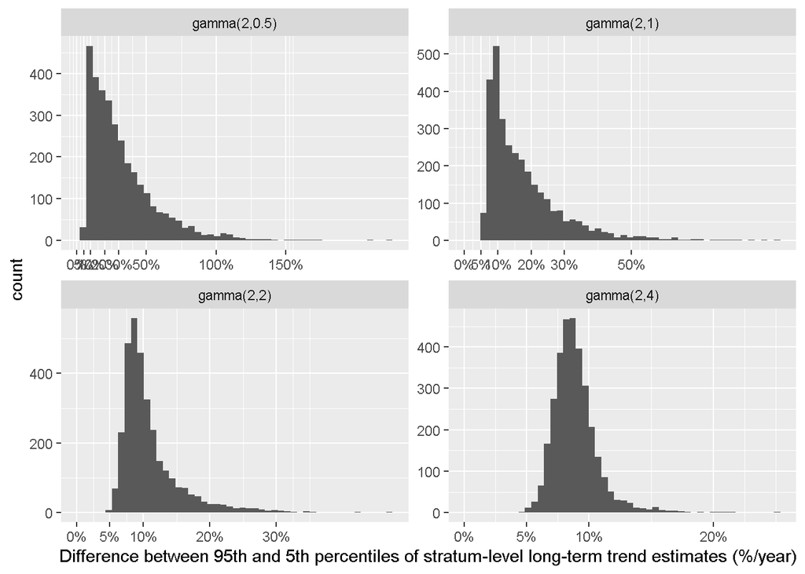

```r
 br = c(0,5,10,20,30,50,100,150)
 lb = paste0(br,"%") #x-axis labels
 ggh_t = ggplot(data = Trends_comp_out,aes(x = span95))+
   geom_histogram(bins = 50)+
   scale_x_continuous(breaks = br,labels = lb,limits = c(0,NA))+
   xlab("Difference between 95th and 5th percentiles of stratum-level long-term trend estimates (%/year)")+
   facet_wrap(~prior_scale,scales = "free")

 print(ggh_t)
```

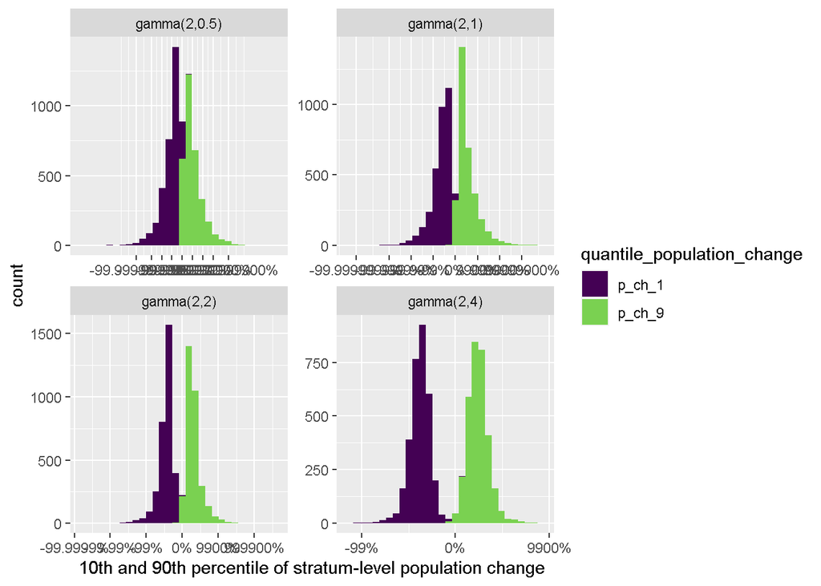

```r
 ch_stack <- Trends_comp_out %>% select(prior_scale,p_ch_1,p_ch_9) %>%
   pivot_longer(.,cols = starts_with("p_ch"),
                                              names_to = "quantile_population_change",
                                              values_to = "Percent_change")



 br = c(c(1/1000000000,1/1000000,1/10000,1/100),c(1,100,10000,1000000,1000000000))
 lb = paste0(c((br-1)*100),"%")
 ggh_p = ggplot(data = ch_stack,aes(x = Percent_change,fill = quantile_population_change))+
   geom_histogram()+
   scale_x_log10(breaks = br,labels = lb)+
   scale_fill_viridis_d(end = 0.8)+
   xlab("10th and 90th percentile of stratum-level population change")+
   facet_wrap(~prior_scale,scales = "free")

 print(ggh_p)
```